# Project 1: SAT & ACT Analysis

## Problem Statement

There has been a change several changes in the participation rates in both the SAT and ACT exams between years 2017 and 2018. This report seeks to explore the reasons for the these changes within the U.S categorized by states. The report also aims to make recommendations to the College Board for strategies to improve participation rates in Ohio.

## Executive Summary

### Contents:

### 2017 Data Import & Cleaning

Errors such as extra characters were rectified and percentages were removed to convert all numerical data in numbers with decimal points.

### 2018 Data Import and Cleaning

Data was found to match the data fields of 2017's data. The cleaned-up data from both 2017 and 2018 were combined to a single data frame for the ease of comparison.

### Exploratory Data Analysis

The standard deviation for each numerical variable were calculated using three different methods. The highest and lowest states were identified in terms of participation rates and scores.

### Data Visualization

Histograms, boxplots, heat maps and scatterplots were used to investigate the data and correlations further.

### Outside Research

Research has been undertaken from the official State Education Departments and other related articles. Some of these include the details of state policies with regards to the compulsory taking of the exams and/or the sponsoring of test fees.

### Conclusions and Recommendations

State departments of education play a pivotal role in increasing the test participation rates. This can come in the form of state subsidies for the test or making the taking of the test mandatory for all school students. The states of West Virgina, Ohio, Rhode Island and Illinois are examples of such policies which greatly impacted SAT participation rates. The SAT Test Day, which happens on a regular school day also contributed to an increase in the overall SAT participation rate.

Focus on collaboration with state education departments, colleges and high schools would likely lead to the continued increase in SAT participation rates.

More research can be done on university admissions criteria in the U.S, SAT test centers and their usage to helps understand how to further drive participation rates.

```python
act_2017.head(10)
```

|  | State | Participation | English | Math | Reading | Science | Composite |
| --- | --- | --- | --- | --- | --- | --- | --- |
| 0 | National | 60% | 20.3 | 20.7 | 21.4 | 21.0 | 21.0 |
| 1 | Alabama | 100% | 18.9 | 18.4 | 19.7 | 19.4 | 19.2 |
| 2 | Alaska | 65% | 18.7 | 19.8 | 20.4 | 19.9 | 19.8 |
| 3 | Arizona | 62% | 18.6 | 19.8 | 20.1 | 19.8 | 19.7 |
| 4 | Arkansas | 100% | 18.9 | 19.0 | 19.7 | 19.5 | 19.4 |
| 5 | California | 31% | 22.5 | 22.7 | 23.1 | 22.2 | 22.8 |
| 6 | Colorado | 100% | 20.1 | 20.3 | 21.2 | 20.9 | 20.8 |
| 7 | Connecticut | 31% | 25.5 | 24.6 | 25.6 | 24.6 | 25.2 |
| 8 | Delaware | 18% | 24.1 | 23.4 | 24.8 | 23.6 | 24.1 |
| 9 | District of Columbia | 32% | 24.4 | 23.5 | 24.9 | 23.5 | 24.2 |

```python
sat_2017.head(10)
```

|  | State | Participation | Evidence-Based Reading and Writing | Math | Total |
| --- | --- | --- | --- | --- | --- |
| 0 | Alabama | 5% | 593 | 572 | 1165 |
| 1 | Alaska | 38% | 547 | 533 | 1080 |
| 2 | Arizona | 30% | 563 | 553 | 1116 |
| 3 | Arkansas | 3% | 614 | 594 | 1208 |
| 4 | California | 53% | 531 | 524 | 1055 |
| 5 | Colorado | 11% | 606 | 595 | 1201 |
| 6 | Connecticut | 100% | 530 | 512 | 1041 |
| 7 | Delaware | 100% | 503 | 492 | 996 |
| 8 | District of Columbia | 100% | 482 | 468 | 950 |
| 9 | Florida | 83% | 520 | 497 | 1017 |

#### 3. Verbally Describe Data

Take your time looking through the data and thoroughly describe the data in the markdown cell below.

Answer: The data sets for SAT and ACT scores are listed according to the states in the United States of America. ACT scores are based on English, Math, Reading and Science while SAT scores are based on Math and Evidence-based Reading and Writing.

#### 4a. Does the data look complete?

Answer: Yes, the data looks complete.

#### 4b. Are there any obvious issues with the observations?

**What is the minimum *possible* value for each test/subtest? What is the maximum *possible* value?**

Consider comparing any questionable values to the sources of your data:

- [SAT](https://blog.collegevine.com/here-are-the-average-sat-scores-by-state/)
- [ACT](https://blog.prepscholar.com/act-scores-by-state-averages-highs-and-lows)

Answer: The ACT composite score has under Wyoming has a value inconsistent with the other states. The total score for SAT has some discrepancies, ranging from -1 to 472.

The minimum possible value for the total SAT score is 400 and the maximum is 1600. The minmium possible value for each section in the SAT is 200 while the maximum is 800.

The minimum possible value for each section in the ACT is 1 and the maximum value is 36.

https://collegereadiness.collegeboard.org/sat/scores/understanding-scores/structure

https://www.act.org/content/act/en/products-and-services/the-act/scores/understanding-your-scores.html

#### 5. What are your data types?

Display the data types of each feature.

```python
sat_2017.dtypes
```

```
State                                 object
Participation                         object
Evidence-Based Reading and Writing     int64
Math                                   int64
Total                                  int64
dtype: object
```

```python
act_2017.dtypes
```

```
State             object
Participation     object
English          float64
Math             float64
Reading          float64
Science          float64
Composite         object
dtype: object
```

What did you learn?

- Do any of them seem odd?
- Which ones are not as they should be?

Answer: The composite scores in the ACT should be an integer instead of an object or a float.

| Feature | Type | Dataset | Description |
| --- | --- | --- | --- |
| **state** | *string* | ACT/SAT | The state in the United States of America. |
| **sat_participation or act_participation** | *float* | ACT/SAT | The percentage expressed as a float on the number of students enrolled in schools |
| **sat_reading_and_writing** | *float* | SAT | The average English reading and writing score in a maximum score of 800. |
| **sat_math** | *float* | SAT | The average math score in a maximum score of 800. |
| **sat_total** | *float* | SAT | The combined score of sat_reading_and_writing and sat_math. |
| **act_english** | *float* | ACT | The average math score in a maximum score of 36. |
| **act_math** | *float* | ACT | The average math score in a maximum score of 36. |
| **act_reading** | *float* | ACT | The average reading score in a maximum score of 36. |
| **act_science** | *float* | ACT | The average science score in a maximum score of 36. |
| **act_composite** | *float* | ACT | The average score calculated by the 4 ACT scores of each state. |

```python
#importing DataBase from csv files
sat_2018 = pd.read_csv('sat_2018.csv')
act_2018 = pd.read_csv('act_2018.csv')

def percent_to_float(x):
    return x/100.0

#changing 'Participation' to be a uniform unit (float)
sat_2018['Participation'] = sat_2018['Participation'].map(remove_percent)
act_2018['Participation'] = act_2018['Participation'].map(percent_to_float)

#changing all integer columns to be floats
sat_2018['Evidence-Based Reading and Writing'] = sat_2018['Evidence-Based Reading and Writing'].astype(float)
sat_2018['Math'] = sat_2018['Math'].astype(float)
sat_2018['Total'] = sat_2018['Total'].astype(float)

#renaming columns
act_2018.rename(columns={act_2018.columns[0]:'state'}, inplace=True)
act_2018.rename(columns={act_2018.columns[1]:'act_participation'}, inplace=True)
act_2018.rename(columns={act_2018.columns[2]:'act_composite'}, inplace=True)
act_2018.rename(columns={act_2018.columns[3]:'act_english'}, inplace=True)
act_2018.rename(columns={act_2018.columns[4]:'act_math'}, inplace=True)
act_2018.rename(columns={act_2018.columns[5]:'act_reading'}, inplace=True)
act_2018.rename(columns={act_2018.columns[6]:'act_science'}, inplace=True)

sat_2018.rename(columns={sat_2018.columns[0]:'state'}, inplace=True)
sat_2018.rename(columns={sat_2018.columns[1]:'sat_participation'}, inplace=True)
sat_2018.rename(columns={sat_2018.columns[2]:'sat_reading_and_writing'}, inplace=True)
sat_2018.rename(columns={sat_2018.columns[3]:'sat_math'}, inplace=True)
sat_2018.rename(columns={sat_2018.columns[4]:'sat_total'}, inplace=True)

#combining SAT and ACT scores of 2018
combined_2018 = pd.merge(act_2018, sat_2018, on='state')

combined_2018
```

|  | state | act_participation | act_composite | act_english | act_math | act_reading | act_science | sat_participation | sat_reading_and_writing | sat_math | sat_total |
| --- | --- | --- | --- | --- | --- | --- | --- | --- | --- | --- | --- |
| 0 | Alabama | 1.00 | 19.1 | 18.9 | 18.3 | 19.6 | 19.0 | 0.06 | 595.0 | 571.0 | 1166.0 |
| 1 | Alaska | 0.33 | 20.8 | 19.8 | 20.6 | 21.6 | 20.7 | 0.43 | 562.0 | 544.0 | 1106.0 |
| 2 | Arizona | 0.66 | 19.2 | 18.2 | 19.4 | 19.5 | 19.2 | 0.29 | 577.0 | 572.0 | 1149.0 |
| 3 | Arkansas | 1.00 | 19.4 | 19.1 | 18.9 | 19.7 | 19.4 | 0.05 | 592.0 | 576.0 | 1169.0 |
| 4 | California | 0.27 | 22.7 | 22.5 | 22.5 | 23.0 | 22.1 | 0.60 | 540.0 | 536.0 | 1076.0 |
| 5 | Colorado | 0.30 | 23.9 | 23.9 | 23.2 | 24.4 | 23.5 | 1.00 | 519.0 | 506.0 | 1025.0 |
| 6 | Connecticut | 0.26 | 25.6 | 26.0 | 24.8 | 26.1 | 24.9 | 1.00 | 535.0 | 519.0 | 1053.0 |
| 7 | Delaware | 0.17 | 23.2 | 23.7 | 23.1 | 24.5 | 23.4 | 1.00 | 505.0 | 492.0 | 998.0 |
| 8 | District of Columbia | 0.32 | 23.6 | 23.7 | 22.7 | 24.4 | 23.0 | 0.92 | 497.0 | 480.0 | 977.0 |
| 9 | Florida | 0.66 | 19.9 | 19.2 | 19.3 | 21.1 | 19.5 | 0.97 | 522.0 | 493.0 | 1014.0 |
| 10 | Georgia | 0.53 | 21.4 | 20.9 | 20.7 | 21.2 | 21.4 | 0.70 | 542.0 | 522.0 | 1064.0 |
| 11 | Hawaii | 0.89 | 18.9 | 18.2 | 19.0 | 19.1 | 19.0 | 0.56 | 550.0 | 549.0 | 1099.0 |
| 12 | Idaho | 0.36 | 22.3 | 21.9 | 21.6 | 23.2 | 22.1 | 1.00 | 508.0 | 493.0 | 1001.0 |
| 13 | Illinois | 0.43 | 23.9 | 24.1 | 23.4 | 24.2 | 23.4 | 0.99 | 513.0 | 506.0 | 1019.0 |
| 14 | Indiana | 0.32 | 22.5 | 21.9 | 22.3 | 23.1 | 22.2 | 0.67 | 546.0 | 539.0 | 1086.0 |
| 15 | Iowa | 0.68 | 21.8 | 21.0 | 21.2 | 22.5 | 22.0 | 0.03 | 634.0 | 631.0 | 1265.0 |
| 16 | Kansas | 0.71 | 21.6 | 21.0 | 21.1 | 22.3 | 21.5 | 0.04 | 633.0 | 631.0 | 1264.0 |
| 17 | Kentucky | 1.00 | 20.2 | 19.9 | 19.7 | 20.8 | 20.1 | 0.04 | 630.0 | 618.0 | 1248.0 |
| 18 | Louisiana | 1.00 | 19.2 | 19.0 | 18.5 | 19.6 | 19.1 | 0.04 | 615.0 | 595.0 | 1210.0 |
| 19 | Maine | 0.07 | 24.0 | 23.8 | 23.6 | 24.7 | 23.4 | 0.99 | 512.0 | 501.0 | 1013.0 |
| 20 | Maryland | 0.31 | 22.5 | 22.1 | 22.0 | 23.1 | 22.2 | 0.76 | 545.0 | 535.0 | 1080.0 |
| 21 | Massachusetts | 0.25 | 25.5 | 25.5 | 25.2 | 25.9 | 24.7 | 0.80 | 562.0 | 563.0 | 1125.0 |
| 22 | Michigan | 0.22 | 24.4 | 24.5 | 23.9 | 24.7 | 23.9 | 1.00 | 511.0 | 499.0 | 1011.0 |
| 23 | Minnesota | 0.99 | 21.3 | 20.2 | 21.4 | 21.7 | 21.4 | 0.04 | 643.0 | 655.0 | 1298.0 |
| 24 | Mississippi | 1.00 | 18.6 | 18.2 | 18.1 | 18.9 | 18.6 | 0.03 | 630.0 | 606.0 | 1236.0 |
| 25 | Missouri | 1.00 | 20.0 | 19.5 | 19.7 | 20.5 | 20.0 | 0.04 | 633.0 | 629.0 | 1262.0 |
| 26 | Montana | 1.00 | 20.0 | 18.7 | 19.9 | 20.7 | 20.0 | 0.10 | 606.0 | 592.0 | 1198.0 |
| 27 | Nebraska | 1.00 | 20.1 | 19.4 | 19.8 | 20.4 | 20.1 | 0.03 | 629.0 | 623.0 | 1252.0 |
| 28 | Nevada | 1.00 | 17.7 | 16.6 | 17.8 | 18.0 | 17.9 | 0.23 | 574.0 | 566.0 | 1140.0 |
| 29 | New Hampshire | 0.16 | 25.1 | 25.1 | 24.7 | 25.6 | 24.4 | 0.96 | 535.0 | 528.0 | 1063.0 |
| 30 | New Jersey | 0.31 | 23.7 | 23.8 | 23.6 | 24.0 | 23.0 | 0.82 | 547.0 | 547.0 | 1094.0 |
| 31 | New Mexico | 0.67 | 19.4 | 18.3 | 19.1 | 20.1 | 19.7 | 0.16 | 552.0 | 540.0 | 1093.0 |
| 32 | New York | 0.27 | 24.5 | 24.2 | 24.2 | 24.9 | 24.2 | 0.79 | 534.0 | 534.0 | 1068.0 |
| 33 | North Carolina | 1.00 | 19.1 | 18.0 | 19.3 | 19.5 | 19.2 | 0.52 | 554.0 | 543.0 | 1098.0 |
| 34 | North Dakota | 0.98 | 20.3 | 19.1 | 20.3 | 20.7 | 20.5 | 0.02 | 640.0 | 643.0 | 1283.0 |
| 35 | Ohio | 1.00 | 20.3 | 19.3 | 20.3 | 20.8 | 20.4 | 0.18 | 552.0 | 547.0 | 1099.0 |
| 36 | Oklahoma | 1.00 | 19.3 | 18.4 | 18.8 | 20.1 | 19.4 | 0.08 | 541.0 | 521.0 | 1062.0 |
| 37 | Oregon | 0.42 | 21.3 | 20.6 | 20.9 | 21.9 | 21.1 | 0.48 | 564.0 | 553.0 | 1117.0 |
| 38 | Pennsylvania | 0.20 | 23.5 | 23.3 | 23.2 | 24.0 | 23.1 | 0.70 | 547.0 | 539.0 | 1086.0 |
| 39 | Rhode Island | 0.15 | 24.2 | 24.4 | 23.6 | 25.0 | 23.5 | 0.97 | 513.0 | 505.0 | 1018.0 |
| 40 | South Carolina | 1.00 | 18.3 | 17.3 | 18.2 | 18.6 | 18.5 | 0.55 | 547.0 | 523.0 | 1070.0 |
| 41 | South Dakota | 0.77 | 21.9 | 20.8 | 21.6 | 22.4 | 22.2 | 0.03 | 622.0 | 618.0 | 1241.0 |
| 42 | Tennessee | 1.00 | 19.6 | 19.4 | 19.1 | 19.9 | 19.6 | 0.06 | 624.0 | 607.0 | 1231.0 |
| 43 | Texas | 0.41 | 20.6 | 19.6 | 20.6 | 21.1 | 20.8 | 0.66 | 520.0 | 512.0 | 1032.0 |
| 44 | Utah | 1.00 | 20.4 | 19.7 | 19.9 | 20.9 | 20.5 | 0.04 | 618.0 | 612.0 | 1230.0 |
| 45 | Vermont | 0.24 | 24.1 | 23.9 | 23.4 | 24.9 | 23.8 | 0.64 | 565.0 | 554.0 | 1120.0 |
| 46 | Virginia | 0.24 | 23.9 | 23.8 | 23.3 | 24.7 | 23.5 | 0.68 | 567.0 | 550.0 | 1117.0 |
| 47 | Washington | 0.24 | 22.2 | 21.4 | 22.2 | 22.7 | 22.0 | 0.69 | 543.0 | 538.0 | 1081.0 |
| 48 | West Virginia | 0.65 | 20.3 | 19.8 | 19.4 | 21.3 | 20.4 | 0.28 | 513.0 | 486.0 | 999.0 |
| 49 | Wisconsin | 1.00 | 20.5 | 19.8 | 20.3 | 20.6 | 20.8 | 0.03 | 641.0 | 653.0 | 1294.0 |
| 50 | Wyoming | 1.00 | 20.0 | 19.0 | 19.7 | 20.6 | 20.3 | 0.03 | 633.0 | 625.0 | 1258.0 |

```python
combined_2017.rename(columns={combined_2017.columns[1]:'act_participation2017'}, inplace=True)
combined_2017.rename(columns={combined_2017.columns[2]:'act_english2017'}, inplace=True)
combined_2017.rename(columns={combined_2017.columns[3]:'act_math2017'}, inplace=True)
combined_2017.rename(columns={combined_2017.columns[4]:'act_reading2017'}, inplace=True)
combined_2017.rename(columns={combined_2017.columns[5]:'act_science2017'}, inplace=True)
combined_2017.rename(columns={combined_2017.columns[6]:'act_composite2017'}, inplace=True)

combined_2017.rename(columns={combined_2017.columns[7]:'sat_participation2017'}, inplace=True)
combined_2017.rename(columns={combined_2017.columns[8]:'sat_reading_and_writing2017'}, inplace=True)
combined_2017.rename(columns={combined_2017.columns[9]:'sat_math2017'}, inplace=True)
combined_2017.rename(columns={combined_2017.columns[10]:'sat_total2017'}, inplace=True)

combined_2018.rename(columns={combined_2018.columns[1]:'act_participation2018'}, inplace=True)
combined_2018.rename(columns={combined_2018.columns[2]:'act_composite2018'}, inplace=True)
combined_2018.rename(columns={combined_2018.columns[3]:'act_english2018'}, inplace=True)
combined_2018.rename(columns={combined_2018.columns[4]:'act_math2018'}, inplace=True)
combined_2018.rename(columns={combined_2018.columns[5]:'act_reading2018'}, inplace=True)
combined_2018.rename(columns={combined_2018.columns[6]:'act_science2018'}, inplace=True)

combined_2018.rename(columns={combined_2018.columns[7]:'sat_participation2018'}, inplace=True)
combined_2018.rename(columns={combined_2018.columns[8]:'sat_reading_and_writing2018'}, inplace=True)
combined_2018.rename(columns={combined_2018.columns[9]:'sat_math2018'}, inplace=True)
combined_2018.rename(columns={combined_2018.columns[10]:'sat_total2018'}, inplace=True)

final = pd.merge(combined_2017, combined_2018, on='state')

final.to_csv(r'./final.csv')
```

#### Investigate trends in the data

Using sorting and/or masking (along with the `.head` method to not print our entire dataframe), consider the following questions:

- Which states have the highest and lowest participation rates for the:
  - 2017 SAT?
  - 2018 SAT?
  - 2017 ACT?
  - 2018 ACT?
- Which states have the highest and lowest mean total/composite scores for the:
  - 2017 SAT?
  - 2018 SAT?
  - 2017 ACT?
  - 2018 ACT?
- Do any states with 100% participation on a given test have a rate change year-to-year?
- Do any states show have >50% participation on *both* tests either year?

Based on what you've just observed, have you identified any states that you're especially interested in? **Make a note of these and state *why* you think they're interesting**.

**You should comment on your findings at each step in a markdown cell below your code block**. Make sure you include at least one example of sorting your dataframe by a column, and one example of using boolean filtering (i.e., masking) to select a subset of the dataframe.

Answer:

The states with 100% participation for the SATs year-to-year experienced a slight change. Connecticut, Michigan and Delaware remained at 100%. Idaho and Colorado achived 100% in 2018 while the District of Columbia only mananged 100% in 2017.

```python
#showing only the state and sat_participation2017 columns
sat_participation2017 = final.loc[:,['state','sat_participation2017']]

#putting the top 5 and bottom 5 states in one DataFrame
sat_participation2017.sort_values(by=['sat_participation2017'], ascending=False).head().append(sat_participation2017.sort_values(by=['sat_participation2017'], ascending=False).tail())
```

|  | state | sat_participation2017 |
| --- | --- | --- |
| 8 | District of Columbia | 1.00 |
| 22 | Michigan | 1.00 |
| 6 | Connecticut | 1.00 |
| 7 | Delaware | 1.00 |
| 29 | New Hampshire | 0.96 |
| 3 | Arkansas | 0.03 |
| 50 | Wyoming | 0.03 |
| 34 | North Dakota | 0.02 |
| 24 | Mississippi | 0.02 |
| 15 | Iowa | 0.02 |

```python
#showing only the state and sat_participation2018 columns
sat_participation2018 = final.loc[:,['state','sat_participation2018']]
#putting the top 5 and bottom 5 states in one DataFrame
sat_participation2018.sort_values(by=['sat_participation2018'], ascending=False).head().append(sat_participation2018.sort_values(by=['sat_participation2018'], ascending=False).tail())
```

|  | state | sat_participation2018 |
| --- | --- | --- |
| 5 | Colorado | 1.00 |
| 6 | Connecticut | 1.00 |
| 7 | Delaware | 1.00 |
| 22 | Michigan | 1.00 |
| 12 | Idaho | 1.00 |
| 24 | Mississippi | 0.03 |
| 15 | Iowa | 0.03 |
| 49 | Wisconsin | 0.03 |
| 50 | Wyoming | 0.03 |
| 34 | North Dakota | 0.02 |

```python
#showing only the state and act_participation2017 columns
act_participation2017 = final.loc[:,['state','act_participation2017']]
#putting the top 5 and bottom 5 states in one DataFrame
act_participation2017.sort_values(by=['act_participation2017'], ascending=False).head().append(act_participation2017.sort_values(by=['act_participation2017'], ascending=False).tail())
```

|  | state | act_participation2017 |
| --- | --- | --- |
| 0 | Alabama | 1.00 |
| 17 | Kentucky | 1.00 |
| 49 | Wisconsin | 1.00 |
| 44 | Utah | 1.00 |
| 42 | Tennessee | 1.00 |
| 38 | Pennsylvania | 0.23 |
| 39 | Rhode Island | 0.21 |
| 7 | Delaware | 0.18 |
| 29 | New Hampshire | 0.18 |
| 19 | Maine | 0.08 |

```python
#showing only the state and act_participation2018 columns
act_participation2018 = final.loc[:,['state','act_participation2018']]
#putting the top 5 and bottom 5 states in one DataFrame
act_participation2018.sort_values(by=['act_participation2018'], ascending=False).head().append(act_participation2018.sort_values(by=['act_participation2018'], ascending=False).tail())
```

|  | state | act_participation2018 |
| --- | --- | --- |
| 0 | Alabama | 1.00 |
| 17 | Kentucky | 1.00 |
| 49 | Wisconsin | 1.00 |
| 44 | Utah | 1.00 |
| 42 | Tennessee | 1.00 |
| 38 | Pennsylvania | 0.20 |
| 7 | Delaware | 0.17 |
| 29 | New Hampshire | 0.16 |
| 39 | Rhode Island | 0.15 |
| 19 | Maine | 0.07 |

```python
#showing only the state and sat_total2017 columns
sat_total2017 = final.loc[:,['state','sat_total2017']]

#putting the top 5 and bottom 5 states in one DataFrame
sat_total2017.sort_values(by=['sat_total2017'], ascending=False).head().append(sat_total2017.sort_values(by=['sat_total2017'], ascending=False).tail())
```

|  | state | sat_total2017 |
| --- | --- | --- |
| 23 | Minnesota | 1295.0 |
| 49 | Wisconsin | 1291.0 |
| 15 | Iowa | 1275.0 |
| 25 | Missouri | 1271.0 |
| 16 | Kansas | 1260.0 |
| 19 | Maine | 1012.0 |
| 12 | Idaho | 1005.0 |
| 22 | Michigan | 1005.0 |
| 7 | Delaware | 996.0 |
| 8 | District of Columbia | 950.0 |

```python
#showing only the state and sat_total2018 columns
sat_total2018 = final.loc[:,['state','sat_total2018']]

#putting the top 5 and bottom 5 states in one DataFrame
sat_total2018.sort_values(by=['sat_total2018'], ascending=False).head().append(sat_total2018.sort_values(by=['sat_total2018'], ascending=False).tail())
```

|  | state | sat_total2018 |
| --- | --- | --- |
| 23 | Minnesota | 1298.0 |
| 49 | Wisconsin | 1294.0 |
| 34 | North Dakota | 1283.0 |
| 15 | Iowa | 1265.0 |
| 16 | Kansas | 1264.0 |
| 22 | Michigan | 1011.0 |
| 12 | Idaho | 1001.0 |
| 48 | West Virginia | 999.0 |
| 7 | Delaware | 998.0 |
| 8 | District of Columbia | 977.0 |

```python
#showing only the state and act_composite2017 columns
act_composite2017 = final.loc[:,['state','act_composite2017']]

#putting the top 5 and bottom 5 states in one DataFrame
act_composite2017.sort_values(by=['act_composite2017'], ascending=False).head().append(act_composite2017.sort_values(by=['act_composite2017'], ascending=False).tail())
```

|  | state | act_composite2017 |
| --- | --- | --- |
| 29 | New Hampshire | 25.5 |
| 21 | Massachusetts | 25.4 |
| 6 | Connecticut | 25.2 |
| 19 | Maine | 24.3 |
| 8 | District of Columbia | 24.2 |
| 33 | North Carolina | 19.1 |
| 11 | Hawaii | 19.0 |
| 40 | South Carolina | 18.7 |
| 24 | Mississippi | 18.6 |
| 28 | Nevada | 17.8 |

```python
#showing only the state and act_composite2018 columns
act_composite2018 = final.loc[:,['state','act_composite2018']]

#putting the top 5 and bottom 5 states in one DataFrame
act_composite2018.sort_values(by=['act_composite2018'], ascending=False).head().append(act_composite2018.sort_values(by=['act_composite2018'], ascending=False).tail())
```

|  | state | act_composite2018 |
| --- | --- | --- |
| 6 | Connecticut | 25.6 |
| 21 | Massachusetts | 25.5 |
| 29 | New Hampshire | 25.1 |
| 32 | New York | 24.5 |
| 22 | Michigan | 24.4 |
| 0 | Alabama | 19.1 |
| 11 | Hawaii | 18.9 |
| 24 | Mississippi | 18.6 |
| 40 | South Carolina | 18.3 |
| 28 | Nevada | 17.7 |

## Visualize the data

There's not a magic bullet recommendation for the right number of plots to understand a given dataset, but visualizing your data is *always* a good idea. Not only does it allow you to quickly convey your findings (even if you have a non-technical audience), it will often reveal trends in your data that escaped you when you were looking only at numbers.

Some recommendations on plotting:

- Plots have titles
- Plots have axis labels
- Plots have appropriate tick labels
- All text is legible in a plot
- Plots demonstrate meaningful and valid relationships
- Plots are interpreted to aid understanding

There is such a thing as too many plots, and there are a *lot* of bad plots. You might make some! (But hopefully not with the guided prompts below).

#### Use Seaborn's heatmap with pandas `.corr()` to visualize correlations between all numeric features

Heatmaps are generally not appropriate for presentations, and should often be excluded from reports as they can be visually overwhelming. **However**, they can be extremely useful in identify relationships of potential interest (as well as identifying potential collinearity before modeling).

*example*:

```
sns.heatmap(df.corr())
```

Please take time to format your output, adding a title. Look through some of the additional arguments and options. (Axis labels aren't really necessary, as long as the title is informative).

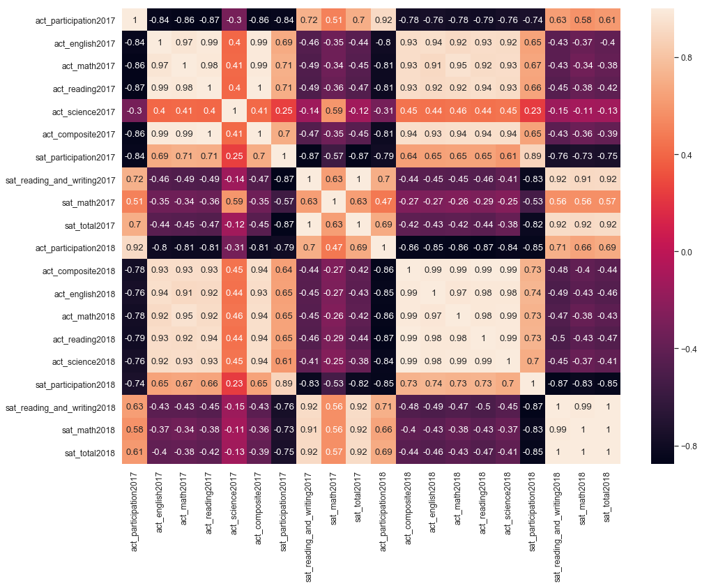

```python
import seaborn as sns
sns.set(font_scale=1.1)
import matplotlib.pyplot as plt

fig, ax = plt.subplots(figsize=(16,12))
sns.heatmap(final.corr(),annot=True)
```

[Helpful Link for Plotting Multiple Figures](https://matplotlib.org/users/pyplot_tutorial.html#working-with-multiple-figures-and-axes)

#### Plot and interpret histograms

For each of the following:

- Participation rates for SAT & ACT
- Math scores for SAT & ACT
- Reading/verbal scores for SAT & ACT

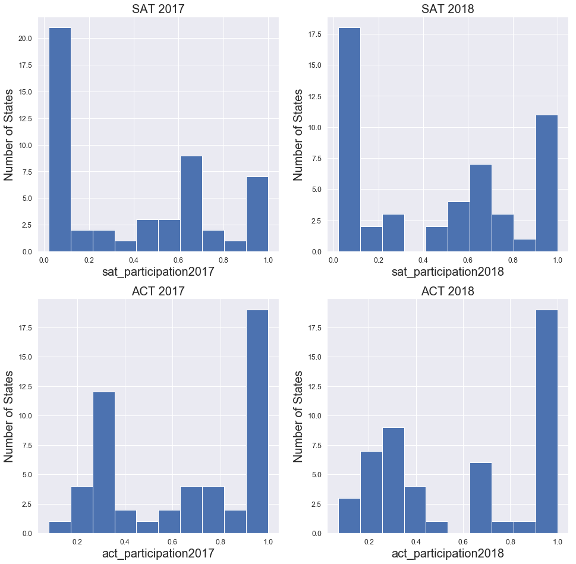

```python
list_of_columns = ['sat_participation2017','sat_participation2018','act_participation2017','act_participation2018']

list_of_titles = ['SAT 2017','SAT 2018','ACT 2017','ACT 2018']

list_of_xlabels = [i for i in list_of_columns]

subplot_histograms(final,list_of_columns,list_of_titles,list_of_xlabels)
```

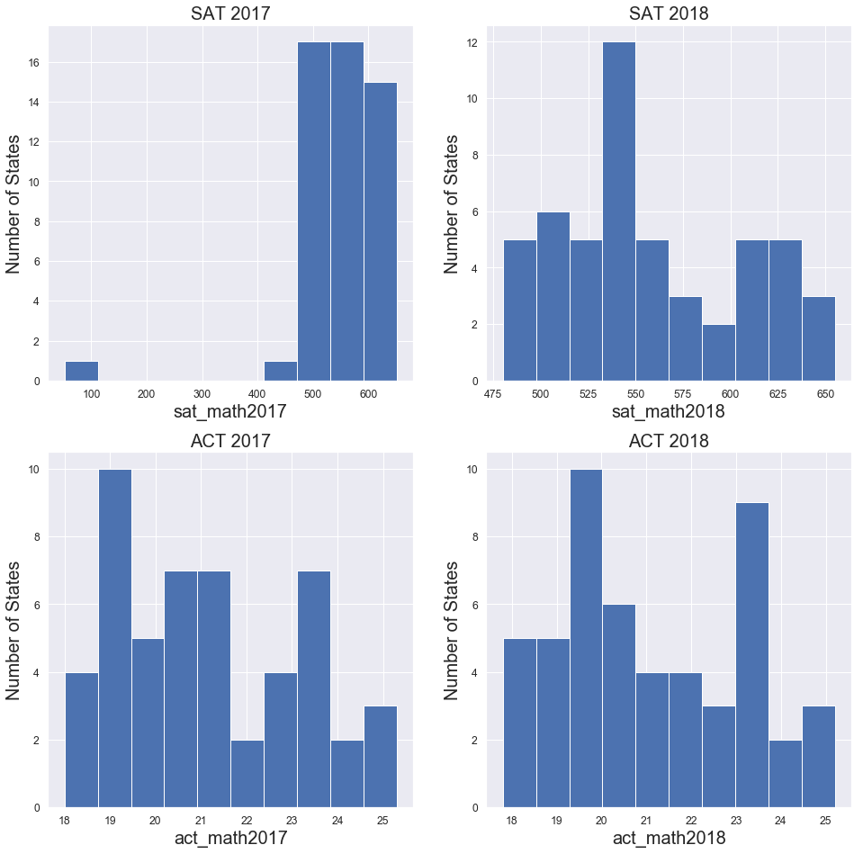

```python
list_of_columns = ['sat_math2017','sat_math2018','act_math2017','act_math2018']

list_of_titles = ['SAT 2017','SAT 2018','ACT 2017','ACT 2018']

list_of_xlabels = [i for i in list_of_columns]

subplot_histograms(final,list_of_columns,list_of_titles,list_of_xlabels)
```

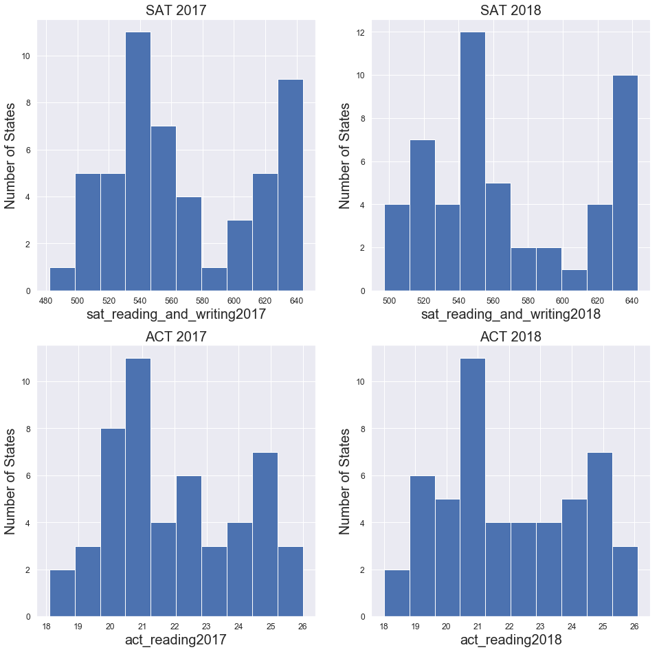

```python
list_of_columns = ['sat_reading_and_writing2017','sat_reading_and_writing2018','act_reading2017','act_reading2018']

list_of_titles = ['SAT 2017','SAT 2018','ACT 2017','ACT 2018']

list_of_xlabels = [i for i in list_of_columns]

subplot_histograms(final,list_of_columns,list_of_titles,list_of_xlabels)
```

#### Plot and interpret scatter plots

For each of the following:

- SAT vs. ACT math scores for 2017
- SAT vs. ACT verbal/reading scores for 2017
- SAT vs. ACT total/composite scores for 2017
- Total scores for SAT 2017 vs. 2018
- Composite scores for ACT 2017 vs. 2018

Plot the two variables against each other using matplotlib or Seaborn

Your plots should show:

- Two clearly labeled axes
- A proper title
- Using colors and symbols that are clear and unmistakable

**Feel free to write a custom function, and subplot if you'd like.** Functions save both time and space.

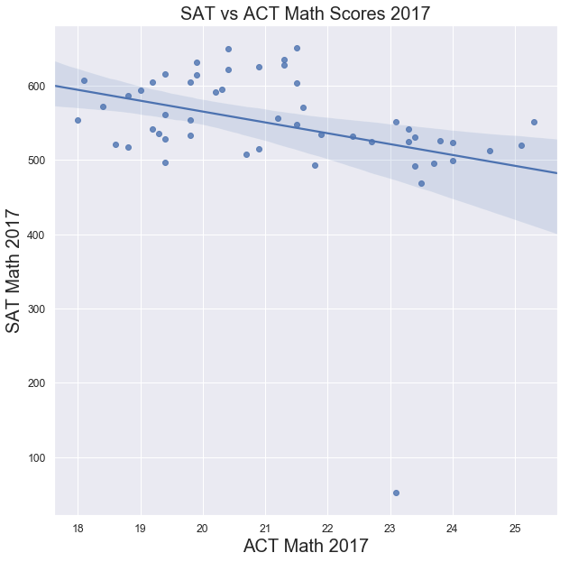

```python
ax = plt.subplots(figsize=(10,10))
ax = sns.regplot(y='sat_math2017', x='act_math2017', data=final[['sat_math2017','act_math2017']])
ax.set_title('SAT vs ACT Math Scores 2017',fontsize=20)
ax.set_xlabel('ACT Math 2017',fontsize=20)
ax.set_ylabel('SAT Math 2017',fontsize=20)
```

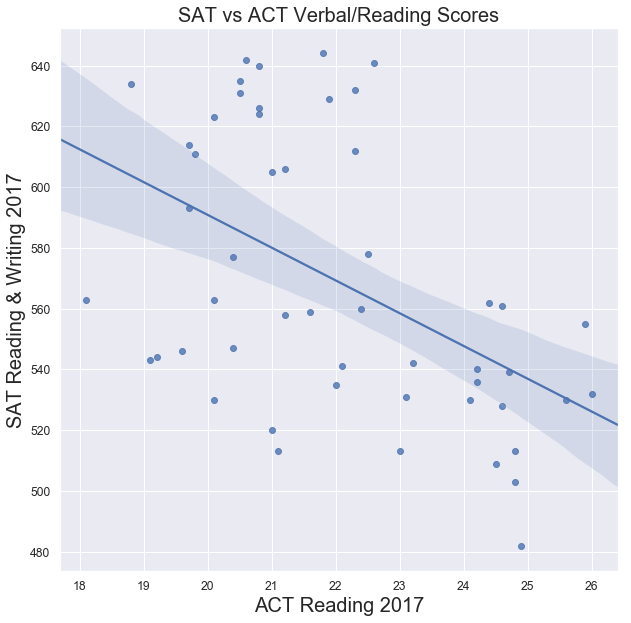

```python
ax = plt.subplots(figsize=(10,10))
ax = sns.regplot(y='sat_reading_and_writing2017', x='act_reading2017', data=final[['sat_reading_and_writing2017','act_reading2017']])
ax.set_title('SAT vs ACT Verbal/Reading Scores',fontsize=20)
ax.set_xlabel('ACT Reading 2017',fontsize=20)
ax.set_ylabel('SAT Reading & Writing 2017',fontsize=20)
```

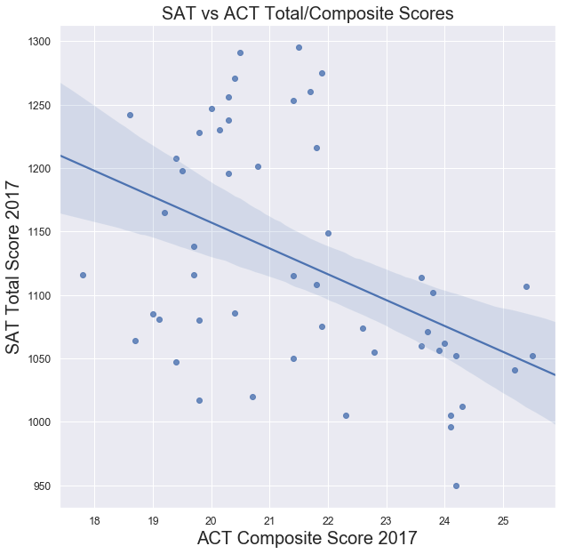

```python
ax = plt.subplots(figsize=(10,10))
ax = sns.regplot(y='sat_total2017', x='act_composite2017', data=final[['sat_total2017','act_composite2017']])
ax.set_title('SAT vs ACT Total/Composite Scores',fontsize=20)
ax.set_xlabel('ACT Composite Score 2017',fontsize=20)
ax.set_ylabel('SAT Total Score 2017',fontsize=20)
```

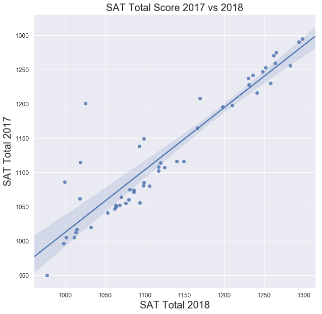

```python
ax = plt.subplots(figsize=(10,10))
ax = sns.regplot(y='sat_total2017', x='sat_total2018', data=final[['sat_total2017','sat_total2018']])
ax.set_title('SAT Total Score 2017 vs 2018',fontsize=20)
ax.set_xlabel('SAT Total 2018',fontsize=20)
ax.set_ylabel('SAT Total 2017',fontsize=20)
```

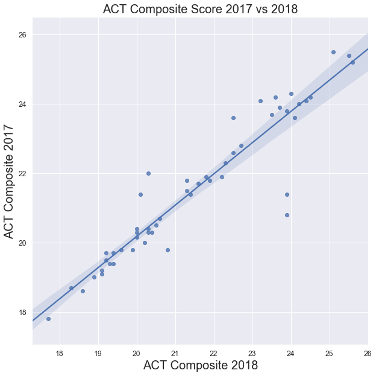

```python
ax = plt.subplots(figsize=(10,10))
ax = sns.regplot(y='act_composite2017', x='act_composite2018', data=final[['act_composite2017','act_composite2018']])
ax.set_title('ACT Composite Score 2017 vs 2018',fontsize=20)
ax.set_xlabel('ACT Composite 2018',fontsize=20)
ax.set_ylabel('ACT Composite 2017',fontsize=20)
```

#### Plot and interpret boxplots

For each numeric variable in the dataframe create a boxplot using Seaborn. Boxplots demonstrate central tendency and spread in variables. In a certain sense, these are somewhat redundant with histograms, but you may be better able to identify clear outliers or differences in IQR, etc.

Multiple values can be plotted to a single boxplot as long as they are of the same relative scale (meaning they have similar min/max values).

Each boxplot should:

- Only include variables of a similar scale
- Have clear labels for each variable
- Have appropriate titles and labels

From the box plots, it can be seen that most of the scores from both tests in both years have a postive skew. Also, the range of the scores seem to be quite consistent year on year.

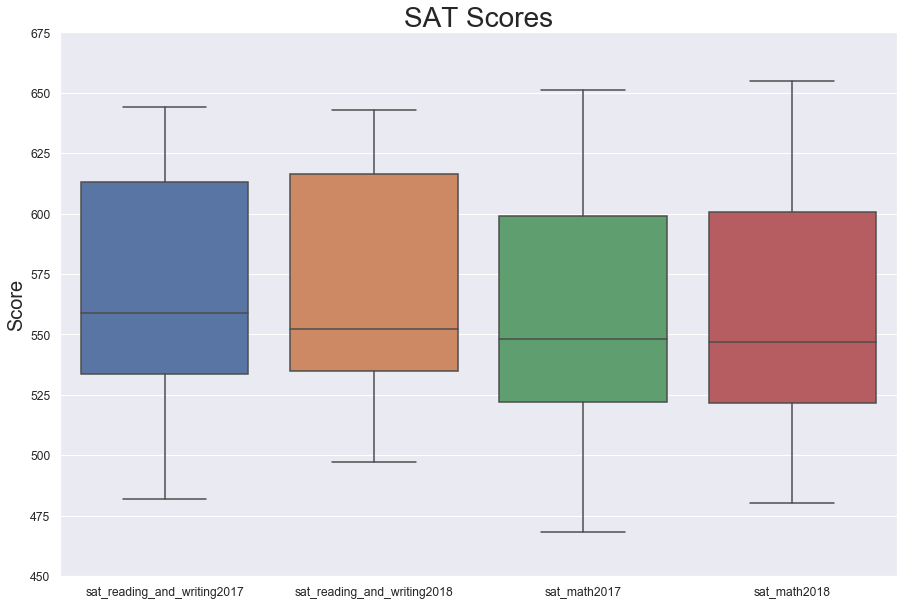

```python
ax = plt.subplots(figsize=(15,10))
plt.title('SAT Scores',fontsize=28)
plt.ylabel('Score',fontsize=20)
plt.ylim(450, 675)
sns.boxplot(data=final[['sat_reading_and_writing2017','sat_reading_and_writing2018','sat_math2017','sat_math2018']],width=0.8)
```

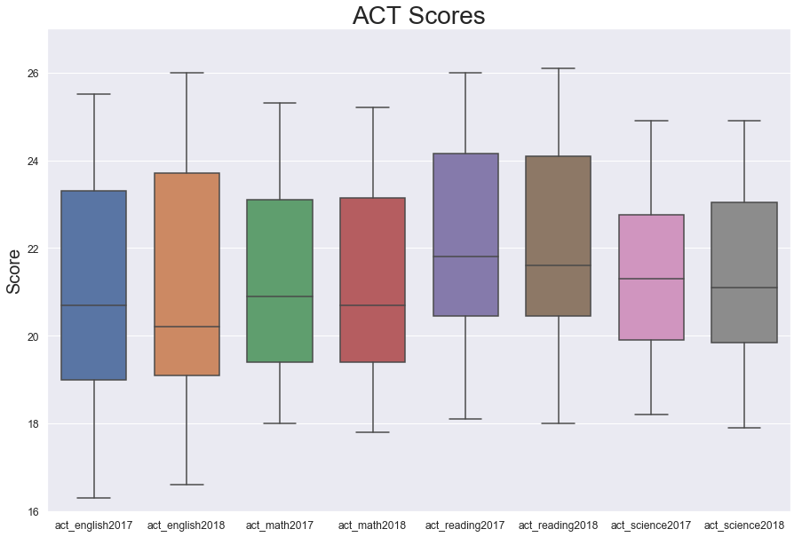

```python
ax = plt.subplots(figsize=(15,10))
plt.title('ACT Scores',fontsize=28)
plt.ylabel('Score',fontsize=20)
plt.ylim(16, 27)

sns.boxplot(data=final[['act_english2017','act_english2018','act_math2017','act_math2018','act_reading2017','act_reading2018','act_science2017','act_science2018']],width=0.7)
```

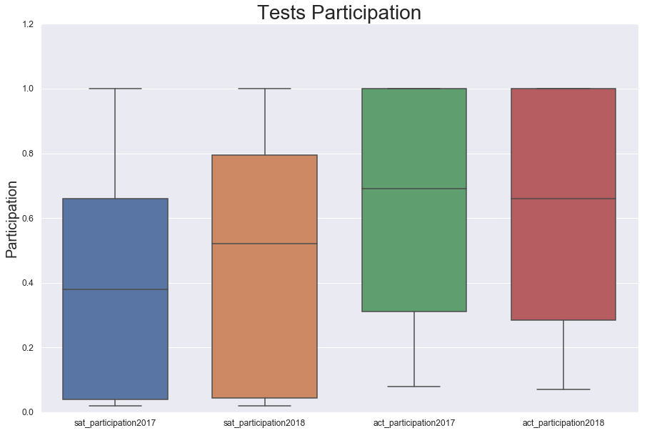

```python
ax = plt.subplots(figsize=(15,10))
plt.title('Tests Participation',fontsize=28)
plt.ylabel('Participation',fontsize=20)
plt.ylim(0, 1.2)

sns.boxplot(data=final[['sat_participation2017','sat_participation2018','act_participation2017','act_participation2018']],width=0.7)
```

```python
#showing the biggest movements in SAT participation
sat_participation_change = pd.DataFrame(final,columns=['state','sat_participation2018','sat_participation2017'])

sat_participation_change['diff'] = sat_participation_change['sat_participation2018'] - sat_participation_change['sat_participation2017']

#putting the top 5 and bottom 5 states in one DataFrame
sat_participation_change.sort_values(['diff'],ascending=False).head().append(sat_participation_change.sort_values(['diff'],ascending=False).tail())
```

|  | state | sat_participation2018 | sat_participation2017 | diff |
| --- | --- | --- | --- | --- |
| 13 | Illinois | 0.99 | 0.09 | 0.90 |
| 5 | Colorado | 1.00 | 0.11 | 0.89 |
| 39 | Rhode Island | 0.97 | 0.71 | 0.26 |
| 48 | West Virginia | 0.28 | 0.14 | 0.14 |
| 9 | Florida | 0.97 | 0.83 | 0.14 |
| 49 | Wisconsin | 0.03 | 0.03 | 0.00 |
| 50 | Wyoming | 0.03 | 0.03 | 0.00 |
| 2 | Arizona | 0.29 | 0.30 | -0.01 |
| 28 | Nevada | 0.23 | 0.26 | -0.03 |
| 8 | District of Columbia | 0.92 | 1.00 | -0.08 |

```python
#showing the biggest movements in ACT participation
act_participation_change = pd.DataFrame(final,columns=['state','act_participation2018','act_participation2017'])

act_participation_change['diff'] = act_participation_change['act_participation2018'] - act_participation_change['act_participation2017']

#putting the top 5 and bottom 5 states in one DataFrame
act_participation_change.sort_values(['diff'],ascending=False).head().append(act_participation_change.sort_values(['diff'],ascending=False).tail())
```

|  | state | act_participation2018 | act_participation2017 | diff |
| --- | --- | --- | --- | --- |
| 35 | Ohio | 1.00 | 0.75 | 0.25 |
| 27 | Nebraska | 1.00 | 0.84 | 0.16 |
| 2 | Arizona | 0.66 | 0.62 | 0.04 |
| 20 | Maryland | 0.31 | 0.28 | 0.03 |
| 37 | Oregon | 0.42 | 0.40 | 0.02 |
| 9 | Florida | 0.66 | 0.73 | -0.07 |
| 22 | Michigan | 0.22 | 0.29 | -0.07 |
| 1 | Alaska | 0.33 | 0.65 | -0.32 |
| 13 | Illinois | 0.43 | 0.93 | -0.50 |
| 5 | Colorado | 0.30 | 1.00 | -0.70 |

## Descriptive and Inferential Statistics

#### We generally assuming that data we sample from a population will be normally distributed. Do we observe this trend?

Answer: As the sample size is more than 30, there is tendency for the data to be normally distributed. However, some of the current data still show a positive skew. Should the sample size be larger, the distribution in comparison would be 'more normal'.

Does This Assumption Hold for:

```
- Math
- Reading
- Rates
```

Explain your answers for each distribution and how you think this will affect estimates made from these data.

As for the participation rates, the assumption does not hold. This is largely due to state level policies which results in skewed distributions.

#### Estimate Limits of Data

Suppose we only seek to understand the relationship between SAT and ACT participation rates in 2017.

##### Does it make sense to conduct statistical inference given these data specifically?

Why or why not?

*(think about granularity, aggregation, the relationships between populations size & rates...consider the actually populations these data describe in answering this question)*

Answer: No it does not make sense to conduct statistical inference given these data. Although all 50 states are reflected in the data, more inferences can be drawn should there be more data points. Also, the participation rates do not reflect the actual number of students taking the tests. Minor changes in participation rates for certain states could actually result in a large increase in the overall number of test takers.

##### Is it appropriate to compare *these* specific SAT and ACT math scores?

Why or why not?

Answer: No it is not appropriate. The SAT (200-800) and ACT math (1-36) scores have very large differences in terms of the scale that they use.

## Outside Research

Based upon your observations, choose **three** states that demonstrate interesting trends in their SAT and/or ACT participation rates. Spend some time doing outside research on state policies that might influence these rates, and summarize your findings below. **Feel free to go back and create new plots that highlight these states of interest**. If you bring in any outside tables or charts, make sure you are explicit about having borrowed them. If you quote any text, make sure that it renders as being quoted. (Make sure that you cite your sources -- check with you local instructor for citation preferences).

PSAT10 and SAT School Day. (n.d.). Retrieved May 23, 2019, from http://www.ride.ri.gov/InstructionAssessment/Assessment/PSATandSAT.aspx

Rado, D. (2016, February 13). Illinois moves ahead with new testing plan, replacing ACT with SAT. Retrieved May 23, 2019, from https://www.chicagotribune.com/news/ct-illinois-chooses-sat-met-20160211-story.html

Colorado SAT. (n.d.). Retrieved May 23, 2019, from https://www.cde.state.co.us/assessment/coloradosat

SAT School Day (High School). (n.d.). Retrieved May 23, 2019, from https://wvde.us/assessment/sat-school-day-high-school/

State-Funded SAT Tests. (n.d.). Retrieved May 23, 2019, from http://education.ohio.gov/Topics/Testing/State-Funded-SAT-Test

Genota, L. (2019, February 20). SAT Scores Rise as Number of Test-Takers Tops 2 Million. Retrieved May 23, 2019, from https://www.edweek.org/ew/articles/2018/10/31/sat-scores-rise-as-number-of-test-takers.html

## Conclusions and Recommendations

Based on your exploration of the data, what are you key takeaways and recommendations? Choose one state with a lower participation rate and provide a suggestion for how the College Board might increase participation amongst graduating seniors in this state. Are there additional data you desire that would better inform your investigations?

#### Key Takeaways

Based on the data, major movements in participation rates are spurred on by the state department of education's policies. If a state were to mandate a requirement for all students to take a particular test, the participation rate for the rate would increase exponentiallly. From further research, we also found that implementation of such policies are usually met on with high opposition from the competition.

Ohio state law requires districts and community schools to administer the state-funded ACT or SAT to all grade 11 students. This has resulted in an increase for participation for both ACT and SAT tests.

Rhode Island has made SAT testing compulsory for all students. This was implemented between 2017 and 2018 and its effects can be seen in the SAT participation, from 71% in 2017 to 97% in 2018.

Illinois, like Rhode Island, has also made SAT testing compulsory for all public high school juniors. This has caused an exponential incrase in SAT participation from 9% to 99%. The ACT partipation rate was halved during this period. It should be noted that this move by the Illinois State Board of Education opposed this decision and is awaiting the final outcome.

In West Virginia, the participation for SAT has doubled from 14% to 28% while ACT saw a decrease by 5%. This can be attributed to the education department's implementation of the SAT School Day where high school students can take the SAT tests on an allocated school day rather than taking in on a weekend and usually at a test center which they do not school at.

Between 2017 and 2018, 10 states (Colorado, Connecticut, Delaware, Idaho, Illinois, Maine, Michigan, New Hampshire, Rhode Island, and West Virginia) and the District of Columbia covered the cost of the SAT for all their public school students. Three years ago, only three states and the District of Columbia did so. This, and the implementation of the SAT School Day contributed to the overall 25% increase in SAT test-takers.

As such, the SAT School Day and the cost subsidy of the SAT can be seen to greatly improve SAT participation rates.

#### Recommendations

Firstly, it is evident that a collaboration witht the states' department of education has the highest and most immediate impact on participation rates of a test. This would be in terms of a mandatory test in all schools within the state.

Having said that, it is also paramount to maintain the working relationships with the states already implementing mandatory tests in their location. This would come in the form of customer service, reliability and efficiency in administering the tests and getting the results.

Success stories can also be seen in states where the education department subsidzes the full costs of the test, making them more accessible to lower income students.

Secondly, the college board should explore working with both high schools and colleges. A college's admission criteria based on either of the tests' score would have an huge impact on the perceived value of the test. The value to colleges of a single type of test for the admissions criteria is that they have a single metric which they can rank their applicants by, rather than having to compare their over two sets of metrics. Colleges have also been observed to be moving away from standardized tests. This issue should also be addressed to prove the need for these tests in providing impartial information about their applicants.

Lastly, further research should be done on the university admissions criteria, the type of test and the scores students have been accepted upon and the composition of students taking both tests. Furthermore, information about the test centers and their usage could also shed some light on the matter. These would help to identify both tatical and strategic targets for College Board to further improve the SAT participation.